# P1

### Sentiment Analysis for IMDb reviews

We will build a classification model to predict whether a movie review from IMDb website is positive or negative using neural networks. We will use the [IMDb Dataset of 50K Movie Reviews](https://www.kaggle.com/lakshmi25npathi/imdb-dataset-of-50k-movie-reviews) from Kaggle for this purpose.

You can run this notebook on [Google Colab](https://colab.research.google.com/).

```python
import pandas as pd
import numpy as np
from numpy.random import seed
seed(10)

# If you are using Google Colab, run the following to upload the dataset
# from google.colab import files
# uploaded = files.upload()

df = pd.read_csv("IMDB Dataset.csv", encoding='utf-8')
df.head()
```

|  | review | sentiment |
| --- | --- | --- |
| 0 | One of the other reviewers has mentioned that ... | positive |
| 1 | A wonderful little production. <br /><br />The... | positive |
| 2 | I thought this was a wonderful way to spend ti... | positive |
| 3 | Basically there's a family where a little boy ... | negative |
| 4 | Petter Mattei's "Love in the Time of Money" is... | positive |

The dataset consists of two columns - review and its sentiment.

Let us check the number of rows and columns in the dataset.

```python
df.shape
```

```
(50000, 2)
```

There are 50,000 movie reviews in total.

Let us check the number of positive and negative reviews in our dataset.

```python
df['sentiment'].value_counts()
```

```
negative    25000
positive    25000
Name: sentiment, dtype: int64
```

The dataset is equally divided into positive and negative reviews.

### Steps for building a sentiment detection model:

- Preprocessing text
  - Cleaning the text
  - Splitting the dataset into training and validation sets
  - Converting the reviews into numerical vectors (vectorization)
- Training a neural network for sentiment detection
  - Defining the architecture of the neural net
  - Training on the dataset
  - Computing accuracy scores on training and validation sets
- Testing the model to detect sentiment for new unseen reviews

Let us peek into one of the movie review.

```python
text = df.iloc[4, 0]
text
```

```
'Petter Mattei\'s "Love in the Time of Money" is a visually stunning film to watch. Mr. Mattei offers us a vivid portrait about human relations. This is a movie that seems to be telling us what money, power and success do to people in the different situations we encounter. <br /><br />This being a v…
```

The text contains HTML tags such as `<br />` that we will remove using regular expressions.

```python
import re
text = re.sub('<.*?>', '', text)
text
```

```
'Petter Mattei\'s "Love in the Time of Money" is a visually stunning film to watch. Mr. Mattei offers us a vivid portrait about human relations. This is a movie that seems to be telling us what money, power and success do to people in the different situations we encounter. This being a variation on …
```

We define a `clean_text` function that we will use below while vectorizing the text.

```python
import re
def clean_text(text):
    text = re.sub(r'<.*?>', '', text) # remove HTML tags
    return text
```

Now we extract our input feature `X` and the target output `y` from the dataframe `df`.

```python
X = df['review']
y = df['sentiment'].replace({'positive': 1, 'negative': 0})
```

Then we split the dataset into train and validation sets.

```python
from sklearn.model_selection import train_test_split
# default is 75% / 25% train-test split

X_train, X_valid, y_train, y_valid = train_test_split(X, y, random_state=0)
```

### Vectorization

Our input `X` consists of texts, which are sequences of words, spaces, punctuations, emojis, etc. and we need to convert these texts into a numerical vectors. There are multiple ways to vectorize the text and we will use TF-IDF vectorization with Bag-Of-Words (BOW) method.

Bag-Of-Words (BOW) method simply means we count the occurence of words without keeping track of the order of words in a sentence. The steps for vectorizing using TF-IDF are as follows:

- We first create a vocabulary of words and compute the size of the vocabulary, say $n$.
- For $n$-dimensional vector, we assign each index to a specific word in the vocabulary.
- Next we iterate through the text samples in the dataset:
  - we compute TF-IDF frequency for each word and
  - we create a vector by assigning the above frequencies in their respective indices and use zeros for the words not present in the sample text.

#### Term Frequency Inverse Document Frequency (TF-IDF)

TF-IDF frequency tweaks the usual frequency so that rarer words are given more weight. Some words such as "wonderful", "disgusting", etc. would be stronger indicators for the sentiment of the reviews than words such as "watching", "become", "every", "after", etc. and hence, it makes sense to use TF-IDF for our project.

$$ \text{TF-IDF} = \text{TF (Term Frequency)} * \text{IDF (Inverse Document Frequency)} $$

Term Frequency (TF) is the number of times a word occur in a review. It is multiplied by Inverse Document Frequency (IDF) which is a measure of the originality of the word. The words that are rarer have higher IDF values and hence, they are weighted more in TF-IDF than their true frequency as compared to commonly occuring words.

$$ \text{Inverse Document Frequency (IDF) for a word} = \log \Bigg( \frac{\text{Total number of reviews}}{\text{Number of reviews that contain this word}}\Bigg)$$

```python
from sklearn.feature_extraction.text import TfidfVectorizer

vectorizer = TfidfVectorizer(stop_words="english",
                             preprocessor=clean_text, # clean_text function defined above
                             max_features=15000)

X_train_vectorized = vectorizer.fit_transform(X_train).toarray()
X_valid_vectorized = vectorizer.transform(X_valid).toarray()
```

### Constructing a simple network

We import the relevant functions from [Keras](https://keras.io/) that we plan to use in our network.

```python
from keras.models import Sequential
from keras.layers import Embedding, Dense, Dropout
from keras.initializers import he_normal
from keras.callbacks import ModelCheckpoint, EarlyStopping


input_dim = X_train_vectorized.shape[1] # size of input variables
```

Let us check the shapes of the training and validation sets.

```python
X_train.shape, X_valid.shape, y_train.shape, y_valid.shape
```

```
((37500,), (12500,), (37500,), (12500,))
```

Let us define a simple neural network with a single hidden layer. We use ReLU for the hidden layer and sigmoid activation for the output layer since it is a binary classification problem.

```python
model = Sequential()
model.add(Dense(units=32, input_dim=input_dim, activation="relu", kernel_initializer=he_normal())) # Hidden layer
model.add(Dropout(0.4)) # Adding dropout regularization to the hidden layer with dropout prob=0.5
model.add(Dense(units=1, activation="sigmoid")) # Output layer
model.summary()
```

```
Model: "sequential"
_________________________________________________________________
Layer (type)                 Output Shape              Param #
=================================================================
dense (Dense)                (None, 32)                480032
_________________________________________________________________
dropout (Dropout)            (None, 32)                0
_________________________________________________________________
dense_1 (Dense)              (None, 1)                 33
=================================================================
Total params: 480,065
Trainable params: 480,065
Non-trainable params: 0
_________________________________________________________________
```

We compile the model by using accuracy as the evaluation metric, ADAM as optimizer and binary cross-entropy loss funtion.

```python
model.compile(optimizer='adam', loss="binary_crossentropy", metrics=["accuracy"])
```

Finally, we train the model while using `EarlyStopping` for the training to stop early if the validation loss is not decreasing any further.

```python
earlystopping = EarlyStopping(monitor='val_loss', mode='min', verbose=1)
model_history = model.fit(X_train_vectorized, y_train,
                          epochs=10, batch_size=256,
                          validation_data=(X_valid_vectorized, y_valid), verbose=1, callbacks=earlystopping);
```

```
Epoch 00006: early stopping
```

We can plot the loss function values for training and validation sets over the epochs using `model_history`.

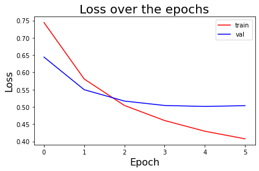

```python
import matplotlib.pyplot as plt
def plot_loss(model_history):
    fig, ax = plt.subplots()
    plt.plot(np.sqrt(model_history.history['loss']), 'r', label='train')
    plt.plot(np.sqrt(model_history.history['val_loss']), 'b' ,label='val')
    ax.set_xlabel(r'Epoch', fontsize=16)
    ax.set_ylabel(r'Loss', fontsize=16)
    plt.legend()
    plt.title("Loss over the epochs", fontsize=20)
    fig.tight_layout()
    plt.show()


plot_loss(model_history)
```

We can also plot the accuracy values for training and validation sets over the epochs using `model_history`.

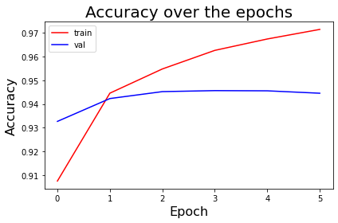

```python
def plot_accuracy(model_history):
    fig, ax = plt.subplots()
    plt.plot(np.sqrt(model_history.history['accuracy']), 'r', label='train')
    plt.plot(np.sqrt(model_history.history['val_accuracy']), 'b' ,label='val')
    ax.set_xlabel(r'Epoch', fontsize=16)
    ax.set_ylabel(r'Accuracy', fontsize=16)
    plt.legend()
    plt.title("Accuracy over the epochs", fontsize=20)
    fig.tight_layout()
    plt.show()
plot_accuracy(model_history)
```

Let us use our trained neural network to predict the sentiment for the movie reviews. Note that the network is giving us the probability that a review is positive, and thus we expect higher probabilities for positive reviews whereas lower probabilities for negative ones.

Let us check with a straightforward positive review.

```python
review1 = ["What a gripping, heart wrenching, hard hitting film..."]
vectorized_review1 = vectorizer.transform(review1).toarray()
model.predict(vectorized_review1)
```

```
array([[0.97009695]], dtype=float32)
```

The model classified the above review correctly as positive with a high probability. Let us now check for a negative review.

```python
review2 = ["That's nothing new in this film."]
vectorized_review2 = vectorizer.transform(review2).toarray()
model.predict(vectorized_review2)
```

```
array([[0.0942305]], dtype=float32)
```

The model again classified the above negative review correctly by giving a low probability score.

Our model is looking at individual words weighted by TF-IDF frequency but it does not take into account the sequence of the words, and thus missing the context. Let us see how it does with more reviews.

```python
review2 = ["If you can keep both eyes open through its whole three-hour length you're a better man than I am."]
vectorized_review2 = vectorizer.transform(review2).toarray()
model.predict(vectorized_review2)
```

```
array([[0.69224685]], dtype=float32)
```

It is getting the prediction wrong by a long margin, probably because most words are neutral except for better which is usually positive. Let us check with another review where sequence of the words matter a lot to get a sense of the sentiment.

```python
review2 = ["In and of itself it is not a bad film."]
vectorized_review2 = vectorizer.transform(review2).toarray()
model.predict(vectorized_review2)
```

```
array([[0.00568324]], dtype=float32)
```

The model got it wrong again. Let us check it with another similar review.

```python
review3 = ["This show was not really funny anymore."]
vectorized_review3 = vectorizer.transform(review3).toarray()
model.predict(vectorized_review3)
```

```
array([[0.8506278]], dtype=float32)
```

Same result as above.

Though we are able to achieve an accuracy score of $~90\%$, the above examples illustrates that the neural network architectures that makes use of the sequence of words in a sentiment might be a better fit for this project.